# 数据加载与包导入

- 将数据从数据局进行导入，引用数据库，数据分析，聚类，可视化等相应的包
- 导入的包 backSpider(数据库操作),pandas(基础操作包)，numpy(基础操作包)，matplotlib（可视化），sklearn（聚类，前期处理），scipy（single信号处理，波峰查找）
- class_id_list：列表，保存品种名称
- all_data：字典，key对应品种名称，value对应该品种下每个样本的拉曼数据，结构为DF，行200-3400，每列一个样本。

```python
from backSpider import *
import pandas as pd
import numpy as np
import matplotlib
# matplotlib.use('tkAgg')
%matplotlib inline
import matplotlib.pyplot as plt
from sklearn.linear_model import LinearRegression
from sklearn.preprocessing import KBinsDiscretizer
from sklearn.tree import DecisionTreeRegressor
from matplotlib.font_manager import FontProperties
from scipy import signal
import warnings
import torch
warnings.filterwarnings("ignore")
mysql = MsSql(db='liurui')
font = FontProperties(fname=r"c:\windows\fonts\simsun.ttc", size=12)
peaks_list = [865, 1260,1339,1382,1461,1527, 1661, 2910]
```

```python
print(torch.__version__)
```

```
2.1.2+cu121
```

```python
class_id = 'qj28 sj2 sj10 lqc3 lh05-379 kd15 kd10 fy305 qj8 lj9 dn416 lj39 lj12 ld12 ss26 ld10 jd58 dn9220 sj3 lj21 '.split() #lj32 kjc5 kc42 dn415
s = ''
for i in class_id:
    s = s + f"'{i}',"
s = s[:-1]
print(s)
```

```
'qj28','sj2','sj10','lqc3','lh05-379','kd15','kd10','fy305','qj8','lj9','dn416','lj39','lj12','ld12','ss26','ld10','jd58','dn9220','sj3','lj21'
```

```python
sql = f"select distinct class from yj_laman_2023_1 where type_id = '34' and class_id in ({s})"
class_id_list = mysql.ExecQuery(sql)
print(len(class_id_list),class_id_list)
```

```
20 [('g_dn9220_34',), ('g_fy305_34',), ('g_jd58_34',), ('g_ld12_34',), ('g_lj12_34',), ('g_sj3_34',), ('k_lj21_34',), ('k_qj28_34',), ('k_ss26_34',), ('z_dn416_34',), ('z_kd10_34',), ('z_kd15_34',), ('z_ld10_34',), ('z_lh05-379_34',), ('z_lj39_34',), ('z_lj9_34',), ('z_lqc3_34',), ('z_qj8_34',), ('z…
```

```python
all_data={}
for class_id in class_id_list:
    sql = f"select class+'_'+emp,d,v from yj_laman_2023_1 where type_id = '34' and class = '{class_id[0]}'"
    data = mysql.ExecQuery(sql)
    df1 = pd.DataFrame(data,columns='class d v'.split())
    df1 = df1.pivot(index='d',columns='class',values='v')
    all_data[class_id[0]] = df1
```

# 数据结构调整

```python
all_data['z_dn416_34']
```

| class d | z_dn416_34_1 | z_dn416_34_10 | z_dn416_34_11 | z_dn416_34_12 | z_dn416_34_13 | z_dn416_34_14 | z_dn416_34_15 | z_dn416_34_16 | z_dn416_34_17 | z_dn416_34_18 | ... | z_dn416_34_30 | z_dn416_34_31 | z_dn416_34_32 | z_dn416_34_33 | z_dn416_34_4 | z_dn416_34_5 | z_dn416_34_6 | z_dn416_34_7 | z_dn416_34_8 | z_dn416_34_9 |
| --- | --- | --- | --- | --- | --- | --- | --- | --- | --- | --- | --- | --- | --- | --- | --- | --- | --- | --- | --- | --- | --- |
| 200 | -63 | -81 | -81 | -59 | -88 | -63 | -71 | -70 | -58 | -55 | ... | -64 | -95 | -79 | -88 | -72 | -62 | -79 | -68 | -52 | -75 |
| 201 | -61 | -82 | -82 | -61 | -88 | -60 | -69 | -68 | -58 | -52 | ... | -70 | -91 | -77 | -88 | -72 | -58 | -77 | -71 | -48 | -69 |
| 202 | -60 | -83 | -84 | -65 | -87 | -59 | -67 | -66 | -60 | -51 | ... | -77 | -90 | -76 | -87 | -71 | -56 | -76 | -75 | -44 | -65 |
| 203 | -61 | -84 | -85 | -69 | -86 | -58 | -67 | -66 | -62 | -52 | ... | -84 | -91 | -78 | -85 | -71 | -55 | -77 | -81 | -42 | -62 |
| 204 | -64 | -83 | -85 | -75 | -84 | -58 | -66 | -67 | -66 | -55 | ... | -90 | -95 | -83 | -82 | -71 | -57 | -79 | -88 | -42 | -61 |
| ... | ... | ... | ... | ... | ... | ... | ... | ... | ... | ... | ... | ... | ... | ... | ... | ... | ... | ... | ... | ... | ... |
| 3396 | 3469 | 2995 | 3490 | 3495 | 4128 | 3289 | 4542 | 2792 | 2717 | 4056 | ... | 3964 | 4380 | 4453 | 4008 | 2753 | 3730 | 2717 | 4843 | 3654 | 2853 |
| 3397 | 3461 | 2989 | 3475 | 3488 | 4115 | 3275 | 4535 | 2794 | 2703 | 4043 | ... | 3941 | 4373 | 4449 | 3994 | 2744 | 3724 | 2706 | 4834 | 3648 | 2836 |
| 3398 | 3456 | 2987 | 3466 | 3481 | 4104 | 3263 | 4529 | 2800 | 2694 | 4029 | ... | 3917 | 4372 | 4445 | 3981 | 2732 | 3723 | 2698 | 4828 | 3644 | 2818 |
| 3399 | 3454 | 2988 | 3463 | 3474 | 4096 | 3255 | 4524 | 2808 | 2688 | 4016 | ... | 3893 | 4377 | 4441 | 3971 | 2719 | 3725 | 2694 | 4826 | 3641 | 2801 |
| 3400 | 3455 | 2991 | 3464 | 3468 | 4091 | 3250 | 4518 | 2816 | 2687 | 4006 | ... | 3872 | 4385 | 4437 | 3965 | 2705 | 3729 | 2693 | 4824 | 3638 | 2786 |

3201 rows × 33 columns

# 归一化和特征提取

```python
def zx_trans(df,window_size = 18):
    ds = df.astype(float)
    ds_shift = ds.copy(deep=True)
    w = window_size #定义小波变换的W
    for col in ds.columns:
        x = np.array(ds[col])
        widths = np.arange(1, w)
        cwtmatr = signal.cwt(x, signal.ricker, widths)
        # 可以修改signal.ricker, 使用自定义的函数来修正小波变换
        y = cwtmatr[w-2]
        ds_shift[col] = y
    return ds_shift
def find_nearest(array,value,nearest=50):
    array = np.asarray(array)
    array1 = np.abs(array - value)
    idx = array1.argmin()
    if (array1[idx] < nearest):
        return idx
    else:
        return -1
def zx_find_peak(ds):
    t = ds
    b,a = signal.butter(2,0.2)
    peak_info = {}
    peaks_list = [865, 1260,1339,1382,1461,1527, 1661, 2910]
    datas = []
    for col,x in t.items():
        X = signal.filtfilt(b, a, x)
        # 查找宽度不小于10，高度不小于75的峰，峰宽高位置为65%处
        peaks,peaks_dic = signal.find_peaks(X,width=10,prominence=100,rel_height=0.65)
        peak_info[col] = [peaks,peaks_dic]
        t_data = []
        for p in peaks_list:
            idx = find_nearest(peak_info[col][0],p-350)
            if (idx>=0):
                t_data.append([peak_info[col][0][idx]+350,p,peak_info[col][1]['prominences'][idx],peak_info[col][1]['width_heights'][idx]])
            else:
                t_data.append([0,0,0,0])
        datas.append(t_data)
    arr = np.array(datas)
    return arr
```

```python
def show_data(ds,title='show_data',show_legend=False):
    ax = ds.plot(alpha=0.6,linewidth=0.5,legend=show_legend)
    # ax.set_title("Original Data")
    ax.set_xlabel(r'Raman shift/$\mathrm{cm}^{-1}$',fontsize=14)
    ax.set_ylabel(r'Intensity/a.u.',fontsize=14)
    ax.get_yaxis().set_major_formatter(matplotlib.ticker.FuncFormatter(lambda x, p: format(int(x), ',')))
    x = list(range(200,3400,100))
    ax.set_xticks(x)
    ax.set_xticklabels(x,rotation=75)
    ax.grid(True)
    # ax.get_xaxis().set_major_formatter(matplotlib.ticker.FuncFormatter(lambda x, p: format(int(x), ',')))
    plt.subplots_adjust(left=0.15, right=0.95, top=0.90, bottom=0.15)
    plt.title(title,FontProperties=font,color='red')
    plt.savefig(f"./"+title+".jpg",dpi=1000,format='jpg')
    plt.show()
def show_3d(data1,data2=None,title=''):
    data = pd.DataFrame(data1, columns=['z1','z2','x', 'y'])
    if (data2 is not None):
        zdata = pd.DataFrame(data2, columns=['z1','z2','x', 'y'])
    fig = plt.figure()
    ax = fig.add_subplot(111, projection='3d')
    ax.scatter(data['x'], data['y'], data['z1']-data['z2'])
    if data2 is not None:
        ax.scatter(zdata['x'], zdata['y'], zdata['z1']-zdata['z2'],color='red')
    ax.set_xlabel('峰高',FontProperties=font)
    ax.set_ylabel('峰宽',FontProperties=font)
    ax.set_zlabel('位置',FontProperties=font)
    plt.title(title,FontProperties=font)
    plt.savefig(f"./show_3d_"+title+".jpg",dpi=600,format='jpg')
    plt.show()
def show_peaks(data1,title=''):
    from scipy.signal import find_peaks,peak_prominences,chirp,peak_widths,find_peaks_cwt
    ax = data1.plot(alpha=0.6,linewidth=0.5,legend=False)
    # ax.set_title("Original Data")
    ax.set_xlabel(r'Raman shift/$\mathrm{cm}^{-1}$',fontsize=14)
    ax.set_ylabel(r'Intensity/a.u.',fontsize=14)
    ax.get_yaxis().set_major_formatter(matplotlib.ticker.FuncFormatter(lambda x, p: format(int(x), ',')))
    x = list(range(200,3400,100))
    ax.set_xticks(x)
    ax.set_xticklabels(x,rotation=75)
    ax.grid(True)
    t = data1
    b,a = signal.butter(2,0.2)
    peak_info = {}
    for col,x in t.items():
        X = signal.filtfilt(b, a, x)
        peaks,peaks_dic = find_peaks(X,width=10,prominence=150,rel_height=0.4)
        peak_info[col] = [peaks,peaks_dic]
        plt.plot(peaks+200, X[peaks], ".", alpha=0.65,linewidth=0.25)
        plt.vlines(x=peaks+200,ymin=X[peaks]-peaks_dic["prominences"]*0.65,ymax=X[peaks],color="C2", alpha=0.75,linewidth=1)
        # plt.hlines(y=peaks_dic["width_heights"],xmin=peaks_dic["left_ips"]+200,xmax=peaks_dic["right_ips"]+200, color="red", alpha=0.75,linewidth=1)
    # leg = plt.legend(loc="upper right", ncol=1, shadow=True, fancybox=True)
    x = list(range(200,3400,100))
    ax.set_xticks(x)
    ax.set_xticklabels(x,rotation=75)
    plt.title(title,FontProperties=font,color='red')
    plt.grid(True)
    plt.savefig(f"./show_peaks.jpg",dpi=1000,format='jpg')
    plt.show()
def show_peaks_loc(data1,title='default'):
    peaks_list = [865, 1260,1339,1382,1461,1527, 1661, 2910]
    _,ax = plt.subplots()
    # ax.plot(ds_shift,alpha=0.75,linewidth=0.3)
    ax.plot(data1,alpha=0.75,linewidth=0.3)
    # ax.plot(ds_shift_list[2],alpha=0.75,linewidth=0.3)
    ax.set_xlabel(r'Raman shift/$\mathrm{cm}^{-1}$',fontsize=14)
    ax.set_ylabel(r'Intensity/a.u.',fontsize=14)
    ax.get_yaxis().set_major_formatter(matplotlib.ticker.FuncFormatter(lambda x, p: format(int(x), ',')))
    ax.get_xaxis().set_major_formatter(matplotlib.ticker.FuncFormatter(lambda x, p: format(int(x), ',')))
    ax.grid(alpha=0.75,linewidth=0.3)
    for peak in peaks_list:
        ax.axvline(peak-56,alpha=0.75,linewidth=0.3,color="r")
        ax.axvline(peak+55,alpha=0.75,linewidth=0.3,color="r")
        ax.text(peak+23, 1000,peak, fontsize=5, color="g", style="italic", weight="light", verticalalignment='center',horizontalalignment='right',rotation=90)
        ax.text(peak+15, 500,112, fontsize=3, color="r", weight="light", verticalalignment='center',horizontalalignment='right')
    plt.subplots_adjust(left=0.15, right=0.95, top=0.95, bottom=0.15)
    x = list(range(200,3400,100))
    ax.set_xticks(x)
    ax.set_xticklabels(x,rotation=75)
    plt.title(title,FontProperties=font,color='red')
    plt.grid(True)
    plt.savefig(f"./"+title+".png",dpi=1000,format='jpg')
    plt.show()
```

```python
all_data_cwt={}
all_data_sift ={}
for id in class_id_list:
    all_data_cwt[id[0]] = zx_trans(all_data[id[0]])
    all_data_sift[id[0]] = zx_find_peak(all_data_cwt[id[0]][150:3000])
```

[figure not shown]

[figure not shown]

[figure not shown]

```python
show_data(all_data['g_lj12_34'][150:3000],'g_sj15_34原始数据')
show_data(all_data_cwt['g_lj12_34'][150:3000],'g_sj15_34小波变换后')
show_peaks_loc(all_data_cwt['g_lj12_34'][150:3000],'g_sj15_34')
```

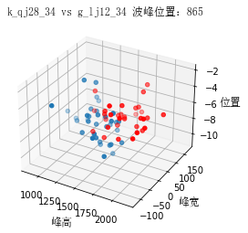

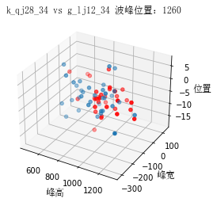

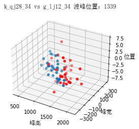

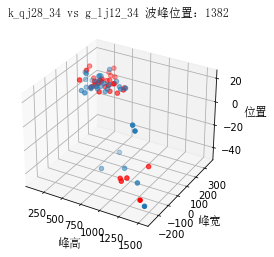

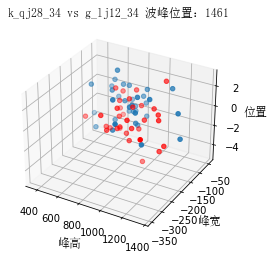

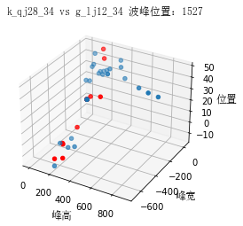

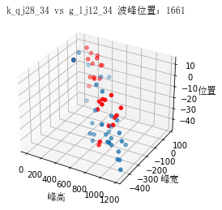

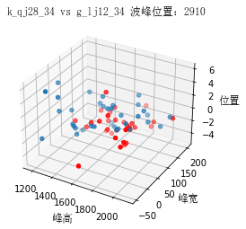

```python
peaks_list = [865, 1260,1339,1382,1461,1527, 1661, 2910]
# col = 4
# print(all_data_sift['k_sj4_34'][:,col,:])
for col in range(8):
    show_3d(all_data_sift['k_qj28_34'][:,col,:],all_data_sift['g_lj12_34'][:,col,:],'k_qj28_34 vs g_lj12_34 波峰位置：'+str(peaks_list[col]))
```

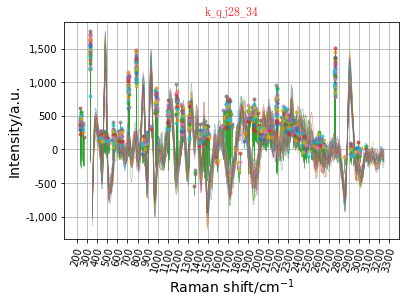

```python
# show_data(all_data_cwt['g_sj15_34'][['g_sj15_34_1','g_sj15_34_11','g_sj15_34_14','g_sj15_34_15']],'g_sj15_34',show_legend=True)
show_peaks(all_data_cwt['k_qj28_34'][150:-150],'k_qj28_34')
```

# 聚类运算

```python
from sklearn import cluster
from sklearn.neighbors import kneighbors_graph
from sklearn.preprocessing import StandardScaler
from sklearn.cluster import SpectralClustering
from itertools import cycle, islice
from sklearn.metrics import silhouette_samples,silhouette_score,calinski_harabasz_score,homogeneity_score,davies_bouldin_score
import os
os.environ["OMP_NUM_THREADS"] = '1'
```

```python
def prepro_data(data):
    arr_3d = data.copy()
    arr_3d[:,:,0] = arr_3d[:,:,0] - arr_3d[:,:,1]
    arr_3d = np.delete(arr_3d, 1,axis=2)
    arr_2d = arr_3d.reshape(arr_3d.shape[0],-1)
    return StandardScaler().fit_transform(arr_2d)
```

```python
from sklearn.cluster import SpectralClustering
from sklearn.neighbors import NearestNeighbors
import numpy as np
def cluster_metrics(cla_id,show_ans=False,n_clusters=3) :
# 假设X是待聚类的样本数据
    X = None
    if isinstance(cla_id,list):
        for cla in cla_id:
            t = prepro_data(all_data_sift[cla])
            if X is not None:
                X = np.concatenate((X,t),axis=0)
            else:
                X = t.copy()
    else:
        X = prepro_data(all_data_sift[cla_id])
    print(X.shape)
    # 使用SpectralClustering进行聚类
    spectral = SpectralClustering(n_clusters=n_clusters, affinity='nearest_neighbors').fit(X)

    # 获取聚类标签
    labels = spectral.labels_

    # 计算每个样本的离散程度
    y_pred = spectral.labels_.astype(int)
    silhouetee_avg = silhouette_score(X, y_pred)
    cal_avg = calinski_harabasz_score(X,y_pred)
    DB_avg = davies_bouldin_score(X,y_pred)

    stds = []
    for i in range(X.shape[0]):
        # 找到同簇的样本索引
        cluster_indices = np.where(labels == labels[i])[0]
        # 计算样本之间的平均距离
        distances = np.mean(np.sqrt(np.sum((X[cluster_indices] - X[i]) ** 2, axis=1)))
        # 计算样本与不同簇样本之间的平均距离（使用最近邻搜索）
        distances_to_other_clusters = []
        for j in range(X.shape[0]):
            if j != i and labels[j] != i:
                distances_to_other_clusters.append(np.sqrt(np.sum((X[i] - X[j]) ** 2)))
        distances_to_other_clusters = np.mean(distances_to_other_clusters)
        # 计算离散程度指标
        std = distances / distances_to_other_clusters
        stds.append(std)
    if show_ans:
        # print(cla_id,'\n',labels)
        print(cla_id)
        for i in range(n_clusters):
            print(i,':',np.count_nonzero(labels == i),end=' | ')
        # print(np.argpartition(stds,5)[:])
        # print(np.argsort(stds))
        print(f"\n轮廓系数：{silhouetee_avg}  方差比标准 CHI：{cal_avg} DB指数：{DB_avg} ")
        # for i in range(len(stds)):
        #     print(f" {i:02d}: {stds[i]:.3f}",end=' ')
        #     if i % 10 ==9:
        #         print()
    return (labels,stds,silhouetee_avg,cal_avg,DB_avg)
```

```python
class_id = {'g':[],'z':[],'k':[]}
# del_cla 列表中保存聚类效果不好，要删除的品种
# del_cla = 'g_lj32_34 k_lj96103_34 z_kd10_34 z_lh05-379_34'.split()
del_cla = []
for id in class_id_list:
    if id[0] in del_cla:
        continue
    class_id[id[0][0]].append(id[0])
print(class_id)
```

```
{'g': ['g_dn9220_34', 'g_fy305_34', 'g_jd58_34', 'g_ld12_34', 'g_lj12_34', 'g_sj3_34'], 'z': ['z_dn416_34', 'z_kd10_34', 'z_kd15_34', 'z_ld10_34', 'z_lh05-379_34', 'z_lj39_34', 'z_lj9_34', 'z_lqc3_34', 'z_qj8_34', 'z_sj10_34', 'z_sj2_34'], 'k': ['k_lj21_34', 'k_qj28_34', 'k_ss26_34']}
```

# 聚类评估

- 评估聚类效果 效果好，保留品种，效果不好，剪裁品种（认定效果不好应小心谨慎）
- 评估样本是否是离群值
- 针对每个品种剪出偏移最多的5个样本，测试后续的机器学习结果。

```python
# 将感，抗，中三种类型的样本集中放在一起进行聚类剪枝，而不是按照品种进行剪枝，看效果。
# 根据聚类结果看，分两类时有明显的大小集合，可以考虑删除其中一个分类组别。
for cla_id in class_id.keys():
    cluster_ans = cluster_metrics(class_id[cla_id],show_ans=True,n_clusters= 2)
    stds = cluster_ans[1]
    delete_col = np.argsort(stds)[-150:]
    cols = []
    for col in class_id[cla_id]:
        cols = cols + list(all_data_cwt[col].columns)
    # print('\n',cols)
    print(cla_id)
    # for i in delete_col:
    #     print(cols[i],end=' ')
    #     all_data_cwt[cla_id[0]].drop(cols[i],axis=1,inplace=True)
    # print(all_data_cwt[cla_id[0]].shape)
    print('\n'+'-'*100)
```

```
(198, 24)
['g_dn9220_34', 'g_fy305_34', 'g_jd58_34', 'g_ld12_34', 'g_lj12_34', 'g_sj3_34']
0 : 178 | 1 : 20 |
轮廓系数：0.19447221948306653  方差比标准 CHI：19.3205936321871 DB指数：1.8573958474400956
g

----------------------------------------------------------------------------------------------------
(362, 24)
['z_dn416_34', 'z_kd10_34', 'z_kd15_34', 'z_ld10_34', 'z_lh05-379_34', 'z_lj39_34', 'z_lj9_34', 'z_lqc3_34', 'z_qj8_34', 'z_sj10_34', 'z_sj2_34']
0 : 37 | 1 : 325 |
轮廓系数：0.19343962761933775  方差比标准 CHI：32.19771991440503 DB指数：2.0106826574683785
z

----------------------------------------------------------------------------------------------------
(101, 24)
['k_lj21_34', 'k_qj28_34', 'k_ss26_34']
0 : 85 | 1 : 16 |
轮廓系数：0.12563179660514512  方差比标准 CHI：9.417647572819828 DB指数：2.287939504818884
k

----------------------------------------------------------------------------------------------------
```

```python
#分品种进行聚类剪枝，每个品种剪出5个样本，看效果。
for cla_id in class_id_list:
    cluster_ans = cluster_metrics(cla_id[0])
    stds = cluster_ans[1]
    delete_col = np.argsort(stds)[-5:]
    cols = all_data_cwt[cla_id[0]].columns
    # print('\n',cols)
    print(col,'\n',all_data_cwt[cla_id[0]].shape)
    for i in delete_col:
        print(cols[i],end=' ')
        all_data_cwt[cla_id[0]].drop(cols[i],axis=1,inplace=True)
    print(all_data_cwt[cla_id[0]].shape)
    print('\n'+'-'*100)
```

[output not shown]

[output cut: 227 more lines]

[output not shown]

# 数据裁剪

根据聚类评估结果对数据进行裁剪，为下一步机器学习做数据准备

### 针对每个品种剪出偏移最多的5个样本，测试后续的机器学习结果。

## 按照不同种子进行分割

```python
print(all_data_cwt['k_qj28_34'].shape)
print(list(all_data_cwt['k_qj28_34'].columns))
all_data_cwt['k_qj28_34']
```

```
(3201, 35)
['k_qj28_34_1', 'k_qj28_34_10', 'k_qj28_34_11', 'k_qj28_34_12', 'k_qj28_34_13', 'k_qj28_34_14', 'k_qj28_34_15', 'k_qj28_34_16', 'k_qj28_34_17', 'k_qj28_34_18', 'k_qj28_34_19', 'k_qj28_34_2', 'k_qj28_34_20', 'k_qj28_34_21', 'k_qj28_34_22', 'k_qj28_34_23', 'k_qj28_34_24', 'k_qj28_34_25', 'k_qj28_34_26…
```

| class d | k_qj28_34_1 | k_qj28_34_10 | k_qj28_34_11 | k_qj28_34_12 | k_qj28_34_13 | k_qj28_34_14 | k_qj28_34_15 | k_qj28_34_16 | k_qj28_34_17 | k_qj28_34_18 | ... | k_qj28_34_32 | k_qj28_34_33 | k_qj28_34_34 | k_qj28_34_35 | k_qj28_34_4 | k_qj28_34_5 | k_qj28_34_6 | k_qj28_34_7 | k_qj28_34_8 | k_qj28_34_9 |
| --- | --- | --- | --- | --- | --- | --- | --- | --- | --- | --- | --- | --- | --- | --- | --- | --- | --- | --- | --- | --- | --- |
| 200 | -687.253284 | -723.079169 | -884.356386 | -954.177255 | -882.761923 | -967.320959 | -718.381532 | -888.009503 | -663.881297 | -871.585318 | ... | -563.260186 | -729.749443 | -822.452882 | -590.733710 | -928.170249 | -738.763761 | -804.697747 | -964.199532 | -855.407032 | -1063.639724 |
| 201 | -765.586232 | -807.082196 | -972.651345 | -1053.565059 | -983.387726 | -1076.287306 | -794.356419 | -984.822913 | -742.971296 | -967.794295 | ... | -630.183348 | -813.635602 | -912.359015 | -661.223503 | -1023.724473 | -821.919716 | -890.083252 | -1065.682358 | -951.927126 | -1172.308511 |
| 202 | -848.180968 | -896.418586 | -1066.188049 | -1159.305372 | -1089.860699 | -1191.556370 | -874.294915 | -1087.039461 | -826.439905 | -1069.660123 | ... | -700.070816 | -902.666753 | -1007.526248 | -735.244053 | -1125.210399 | -909.510899 | -980.743568 | -1172.908646 | -1053.683021 | -1286.651496 |
| 203 | -935.040462 | -991.199519 | -1165.099483 | -1271.548875 | -1202.191497 | -1313.124714 | -958.243842 | -1194.693731 | -914.268724 | -1177.240401 | ... | -772.871692 | -996.920256 | -1108.003932 | -812.752357 | -1232.753635 | -1001.555460 | -1076.803755 | -1285.962504 | -1160.712038 | -1406.685162 |
| 204 | -1026.160398 | -1091.526562 | -1269.514081 | -1390.430871 | -1320.371579 | -1440.965611 | -1046.251863 | -1307.809792 | -1006.429091 | -1290.577288 | ... | -848.538870 | -1096.462099 | -1213.826072 | -893.700101 | -1346.465632 | -1098.068889 | -1178.380243 | -1404.920773 | -1273.050258 | -1532.416753 |
| ... | ... | ... | ... | ... | ... | ... | ... | ... | ... | ... | ... | ... | ... | ... | ... | ... | ... | ... | ... | ... | ... |
| 3396 | 2042.127162 | 3514.001507 | 2968.913570 | 2362.898516 | 1588.461119 | 1929.071302 | 1982.647194 | 2314.793683 | 2090.839980 | 2380.547257 | ... | 1688.507506 | 2080.012837 | 2558.735608 | 1524.835802 | 2630.561147 | 2976.053071 | 3525.345230 | 2478.048209 | 3052.823262 | 1984.420979 |
| 3397 | 1576.638483 | 2734.005372 | 2298.752521 | 1813.899340 | 1226.572163 | 1474.480266 | 1526.356659 | 1801.337639 | 1632.642723 | 1825.939485 | ... | 1308.455000 | 1617.386541 | 1988.545341 | 1187.750892 | 2050.549372 | 2321.675550 | 2748.357084 | 1918.001630 | 2354.110740 | 1502.825317 |
| 3398 | 1092.521187 | 1921.577809 | 1601.192975 | 1243.174706 | 849.676629 | 1001.333465 | 1052.048471 | 1266.605729 | 1155.362272 | 1249.278966 | ... | 912.856681 | 1135.472581 | 1394.795880 | 836.584303 | 1446.403726 | 1640.315493 | 1939.731330 | 1335.018257 | 1627.742707 | 1001.782972 |
| 3399 | 594.574075 | 1084.807099 | 883.154910 | 656.369804 | 461.546145 | 514.318061 | 564.426793 | 715.932121 | 663.722875 | 656.258875 | ... | 505.624112 | 639.070417 | 783.354155 | 474.823350 | 824.121212 | 938.715236 | 1107.459380 | 734.875889 | 880.865531 | 486.266064 |
| 3400 | 87.841431 | 232.210600 | 151.922124 | 59.417107 | 66.148661 | 18.371419 | 68.432655 | 154.929681 | 162.703564 | 52.866697 | ... | 90.876167 | 133.234702 | 160.403408 | 106.142802 | 190.019905 | 223.975185 | 259.950694 | 123.657429 | 120.993968 | -38.492199 |

3201 rows × 35 columns

```python
y_train = []
y_test =[]
col_train = []
col_test = []
class_count = {}
class_key = {'g':0,'k':2,'z':1}
import random
def set_class(class_list,class_label,col_train,col_test):
    y_train = []
    y_test =[]
    for c in class_list:
        sample_n = all_data_cwt[c].shape[1]
        sample = list(all_data_cwt[c].columns)
        random.shuffle(sample)
        n = int(all_data_cwt[c].shape[1]*0.8)
        class_count[c] = (n,sample_n-n)
        for i in sample[:n]:
            col_train.append(i)
        for i in sample[n:]:
            col_test.append(i)
        y_train = y_train+[class_label]*n
        y_test = y_test +[class_label]*(sample_n-n)
    return (y_train,y_test)
for key in class_id.keys():
    t1,t2 = set_class(class_id[key],class_key[key],col_train,col_test)
    y_train = y_train + t1
    y_test = y_test + t2
count_class = {'train':{},'test':{}}
for i in y_train:
    if i in count_class['train'].keys():
        count_class['train'][i]+=1
    else:
        count_class['train'][i]=1
for i in y_test:
    if i in count_class['test'].keys():
        count_class['test'][i]+=1
    else:
        count_class['test'][i]=1
print(count_class)
print(class_count)
print(col_train)
print(col_test)
```

```
{'train': {0: 156, 1: 285, 2: 80}, 'test': {0: 42, 1: 77, 2: 21}}
{'g_dn9220_34': (26, 7), 'g_fy305_34': (26, 7), 'g_jd58_34': (26, 7), 'g_ld12_34': (26, 7), 'g_lj12_34': (26, 7), 'g_sj3_34': (26, 7), 'z_dn416_34': (26, 7), 'z_kd10_34': (26, 7), 'z_kd15_34': (26, 7), 'z_ld10_34': (26, 7), 'z_lh05-379_34': (26, 7), 'z_lj39_34': (26, 7), 'z_lj9_34': (26, 7), 'z_lqc3…
['g_dn9220_34_29', 'g_dn9220_34_13', 'g_dn9220_34_31', 'g_dn9220_34_18', 'g_dn9220_34_16', 'g_dn9220_34_30', 'g_dn9220_34_32', 'g_dn9220_34_21', 'g_dn9220_34_3', 'g_dn9220_34_24', 'g_dn9220_34_2', 'g_dn9220_34_22', 'g_dn9220_34_28', 'g_dn9220_34_27', 'g_dn9220_34_15', 'g_dn9220_34_6', 'g_dn9220_34_1…
['g_dn9220_34_14', 'g_dn9220_34_19', 'g_dn9220_34_5', 'g_dn9220_34_10', 'g_dn9220_34_4', 'g_dn9220_34_26', 'g_dn9220_34_20', 'g_fy305_34_13', 'g_fy305_34_31', 'g_fy305_34_15', 'g_fy305_34_26', 'g_fy305_34_32', 'g_fy305_34_20', 'g_fy305_34_3', 'g_jd58_34_10', 'g_jd58_34_27', 'g_jd58_34_29', 'g_jd58_3…
```

# 机器学习常用方法进行分类实验

## 数据准备

通过提取到的特征，我们可以将数据集分为训练集和测试集。训练集用于训练模型，测试集用于评估模型的性能。

```python
from sklearn.model_selection import train_test_split
# 分割样本集，得到训练集和测试集
ml_x = []
ml_y = []
class_key = {'g':0,'k':2,'z':1}
for id in all_data_sift.keys():
    # print(id,all_data_sift[id].shape)
    for emp in all_data_sift[id]:
        ml_x.append(np.reshape(emp,(1,-1))[0])
        ml_y.append(class_key[id[0]])
ml_x = np.array(ml_x)
ml_y = np.array(ml_y)
print(ml_x.shape,ml_y.shape)
ml_x_train,ml_x_test,ml_y_train,ml_y_test = train_test_split(ml_x,ml_y,test_size=0.2,random_state=0)
print(ml_x_train.shape,ml_y_train.shape,ml_x_test.shape,ml_y_test.shape)
```

```
(661, 32) (661,)
(528, 32) (528,) (133, 32) (133,)
```

## 逻辑回归实验

```python
from sklearn.linear_model import LogisticRegression
from sklearn import metrics
lr = LogisticRegression()
lr.fit(ml_x_train,ml_y_train)
y_prob = lr.predict_proba(ml_x_test)[:1]
y_pred = lr.predict(ml_x_test)
# print(y_prob)
# fpr_lr,tpr_lr,threshold_lr = metrics.roc_curve(y_test,y_prob)
# acu_lr = metrics.acu(fpr_lr,tpr_lr)
source_lr = metrics.accuracy_score(ml_y_test,y_pred)
print('逻辑回归准确率：%.2f%%' % (source_lr*100))
```

```
逻辑回归准确率：67.67%
```

## svm支持向量机实验

```python
from sklearn.svm import SVC
from sklearn.decomposition import PCA
from sklearn.pipeline import Pipeline
from sklearn.preprocessing import StandardScaler
poly_kernel_svm_clf = Pipeline([('scaler',StandardScaler()),('svm_clf',SVC(kernel='rbf',random_state=1))])
poly_kernel_svm_clf.fit(ml_x_train,ml_y_train)
source_svm = poly_kernel_svm_clf.score(ml_x_test,ml_y_test)
print('支持向量机准确率：%.2f%%' % (source_svm*100))
```

```
支持向量机准确率：72.93%
```

### svm尝试采用不同的核函数进行分类 rbf核函数 linear核函数 poly核函数 sigmoid核函数

```python
from sklearn.svm import SVC
from sklearn import metrics

kernelList = 'rbf,linear,sigmoid,poly'.split(',')
# kernelList = ['rbf']
wrongs = {}
for kernel in kernelList:
    svm = SVC(kernel=kernel,random_state=1,C=1)
    svm.fit(ml_x_train,ml_y_train)
    # y_prod = svm.decision_function(x_test)
    # y_pred = svm.predict(x_test)
    y_prod = svm.decision_function(ml_x_test)
    y_pred = svm.predict(ml_x_test)
    # fpr_svm,tpr_svm,threshold_svm = metrics.roc_curve(y_test,y_prob)
    # acu_svm = metrics.acu(fpr_svm,tpr_svm)
    source_svm = metrics.accuracy_score(ml_y_test,y_pred)
#     print(kernel,source_svm)
    print(kernel,'核函数，支持向量机准确率：%.2f%%' % (source_svm*100), svm.intercept_)
```

```
rbf 核函数，支持向量机准确率：57.89% [-0.48285637  0.63204472  0.93994325]
linear 核函数，支持向量机准确率：71.43% [12933.48632746  8761.95000354  3063.756902  ]
sigmoid 核函数，支持向量机准确率：57.89% [-1.61543887  0.59952023  1.38790086]
poly 核函数，支持向量机准确率：65.41% [-2.05228402  0.40992101  0.51231766]
```

## 随机森林实验 尝试不同参数的效果

```python
from sklearn.ensemble import RandomForestClassifier
from sklearn import metrics
for i in range(10,101,10):
    forest = RandomForestClassifier(criterion='entropy',n_estimators=i,random_state=1,n_jobs=2)
    forest.fit(ml_x_train,ml_y_train)
    y_pred = forest.predict(ml_x_test)
    source_forest = metrics.accuracy_score(ml_y_test,y_pred)
#     print(i,source_forest)
    print(i,'棵树的随机森林准确率：%.2f%%' % (source_forest*100))
```

```
10 棵树的随机森林准确率：65.41%
20 棵树的随机森林准确率：68.42%
30 棵树的随机森林准确率：66.17%
40 棵树的随机森林准确率：67.67%
50 棵树的随机森林准确率：66.92%
60 棵树的随机森林准确率：66.17%
70 棵树的随机森林准确率：64.66%
80 棵树的随机森林准确率：67.67%
90 棵树的随机森林准确率：66.92%
100 棵树的随机森林准确率：66.92%
```

## 决策树算法实验 尝试采用不同深度的决策树进行分类，并比较不同深度的决策树的分类效果。

```python
from sklearn.tree import DecisionTreeClassifier
from sklearn import metrics
for i in range(3,10):
    tree = DecisionTreeClassifier(criterion='entropy',max_depth=i,random_state=1)
    tree.fit(ml_x_train,ml_y_train)
    y_pred = forest.predict(ml_x_test)
    source_tree = metrics.accuracy_score(ml_y_test,y_pred)
#     print(i,source_tree)
    print('最大深度为',i,'的决策树准确率：%.2f%%' % (source_tree*100))
```

```
最大深度为 3 的决策树准确率：66.92%
最大深度为 4 的决策树准确率：66.92%
最大深度为 5 的决策树准确率：66.92%
最大深度为 6 的决策树准确率：66.92%
最大深度为 7 的决策树准确率：66.92%
最大深度为 8 的决策树准确率：66.92%
最大深度为 9 的决策树准确率：66.92%
```

## 数据转置

```python
# df_del_col = pd.read_csv("train_result1.csv")
# del_col_train = list(df_del_col.loc[df_del_col['ans'] == False]['col_id'])
# col_train = list(set(col_train)-set(del_col_train))
# print('col_train : ',len(col_train))
# df_del_col = pd.read_csv("test_result1.csv")
# del_col_train = list(df_del_col.loc[df_del_col['ans'] == False]['col_id'])
# col_test = list(set(col_test)-set(del_col_train))
# print('col_test : ',len(col_test))
```

```
class  g_dn9220_34_1  g_dn9220_34_10  g_dn9220_34_11  g_dn9220_34_12  \
d
809      -159.857887      163.134094     -244.280082       37.425452
810      -156.323240      173.442371     -247.656308       32.093697
811      -150.935749      181.876023     -249.981103       27.001352
812      -143.748883      188.460063     -251.167599       22.203179
813      -134.840694      193.261011     -251.107420       17.753948

class  g_dn9220_34_13  g_dn9220_34_14  g_dn9220_34_15  g_dn9220_34_16  \
d
809        -30.936430     -124.235711      305.579560      -28.790698
810        -27.332175     -118.000796      314.078604      -25.051311
811        -23.427855     -111.282306      321.611914      -21.447855
812        -19.313100     -104.070928      328.196914      -17.971256
813        -15.068335      -96.337513      333.854371      -14.598764

class  g_dn9220_34_17  g_dn9220_34_18  ...  z_sj2_34_30  z_sj2_34_31  \
d                                      ...
809        -91.633073      122.998739  ...    57.199057    11.307521
810        -88.946039      110.499479  ...    44.999524    -6.617797
811        -84.724537       96.775196  ...    32.846329   -23.487929
812        -78.927182       82.064989  ...    20.871620   -39.110018
813        -71.523823       66.628896  ...     9.215583   -53.297346

class  z_sj2_34_32  z_sj2_34_33  z_sj2_34_4  z_sj2_34_5  z_sj2_34_6  \
d
809    -263.363780    18.225202  -63.697983  -41.506628  130.441896
810    -271.629773    13.915680  -63.390097  -30.527786  112.936144
811    -277.832817    10.402821  -62.207078  -18.292509   95.362645
812    -281.823023     7.823844  -60.092880   -4.939976   77.955630
813    -283.459484     6.304383  -56.997308    9.387680   60.954914

class  z_sj2_34_7  z_sj2_34_8  z_sj2_34_9
d
809     13.296175 -144.706363    9.083519
810     11.793907 -137.107793   -7.378141
811     12.077175 -127.444591  -22.902185
812     14.177327 -115.843947  -37.205844
813     18.100082 -102.453269  -50.001875

[5 rows x 661 columns]
```

[figure not shown]

```python
peaks_list = [865, 1260,1360,1461,1561, 1661, 2910]
ds = None
for col in all_data_cwt.keys():
    if col in del_cla:
        continue
    ds_shift = all_data_cwt[col]
    peak = peaks_list[0]
    ds2 = ds_shift.loc[peak-56:peak+55]
    for peak in peaks_list[1:]:
        ds2 = pd.concat([ds2,ds_shift.loc[peak-56:peak+55]],axis=0)
    # ds2.set_index('d')
    # print(ds2.columns,ds2.index)
    if ds is None:
        ds = ds2.copy(deep=True)
    else:
        ds = pd.concat([ds,ds2],axis=1)

print(ds.head())
show_data(ds,title='全部数据(删除离群数据)')

x_train = ds[col_train].copy(deep=True)
x_test = ds[col_test].copy(deep=True)
```

```python
train_data_x = np.array(x_train)
train_data_x = train_data_x.T
test_data_x = np.array(x_test)
test_data_x = test_data_x.T
print(train_data_x.shape,test_data_x.shape)
```

```
(521, 784) (140, 784)
```

## 一维结构转二维结构

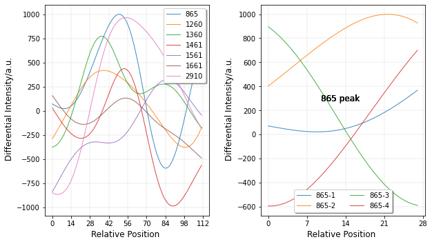

```python
fig, (ax2,ax1) = plt.subplots(1,2,figsize=(9,5))
fig.tight_layout(h_pad=3,w_pad=5)
for i in range(4):
    ax1.plot(train_data_x[0][i*28:(i+1)*28],alpha=0.85,linewidth=1,label='865-'+str(i+1))
    ax1.text(13,300,"865 peak", fontsize=12, color="black", verticalalignment='center',horizontalalignment='center')
for i,peak in enumerate(peaks_list):
    ax2.plot(train_data_x[0][i*112:(i+1)*112],alpha=0.85,linewidth=1,label=str(peak))
ax1.grid(alpha=0.75,linewidth=0.3)
ax2.grid(alpha=0.75,linewidth=0.3)
ax1.set_xlabel(r'Relative Position ',fontsize=12)
ax1.set_ylabel(r' Differential Intensity/a.u.',fontsize=12)
ax2.set_xlabel(r'Relative Position ',fontsize=12)
ax2.set_ylabel(r' Differential Intensity/a.u.',fontsize=12)
ax1.set_xticks([0,7,14,21,28])
ax2.set_xticks([0,14,28,42,56,70,84,98,112])
leg = ax2.legend(loc="upper right", ncol=1, shadow=True, fancybox=True)
leg = ax1.legend(loc="lower center", ncol=2, shadow=True, fancybox=True)
plt.subplots_adjust(left=0.1, right=0.95, top=0.95, bottom=0.1)
plt.savefig(f"./cat_peak.png",dpi=1000,format='jpg')
plt.show()
```

```python
def set_array(X,new_size):
    temp = []
    for i in range(len(X)):
        temp.append(np.reshape(X[i],new_size))
    return np.array(temp)
train_data_x = set_array(train_data_x,(1,28,28))
test_data_x = set_array(test_data_x,(1,28,28))
print(train_data_x.shape,test_data_x.shape)
```

```
(521, 1, 28, 28) (140, 1, 28, 28)
```

# 机器学习

将数据带入模型，可以考虑多几个模型进行比较，比如svm等

## 构造DataLoader对象

```python
import pandas as pd
import numpy as np
from torch.utils.data import Dataset, DataLoader
from torchvision import datasets, transforms
# 自定义Dataset的子类
class MyDataset(Dataset):
    # 构造器初始化方法
    def __init__(self, data_X, data_y):
        self.data_X = data_X
        self.data_y = data_y
    # 重写getitem方法用于通过idx获取数据内容
    def __getitem__(self, idx):
        return self.data_X[idx], self.data_y[idx]
    # 重写len方法获取数据集大小
    def __len__(self):
        return self.data_X.shape[0]
# 构造Dataset对象
train_data = MyDataset(train_data_x, y_train)
test_data = MyDataset(test_data_x, y_test)
# 构造DataLoader对象
train_loader = DataLoader(train_data, batch_size=64,shuffle=True)
test_loader = DataLoader(test_data, batch_size=16,shuffle=True)
```

## 定义胶囊网络结构

```python
from __future__ import print_function

# pytorch
import torch
# 神经网络
import torch.nn as nn
# 神经网络中的常用函数，包括卷积函数，polling函数，激活函数，损失函数，啥函数都有
import torch.nn.functional as F
# 数学包
import math
# 实现各种优化算法的软件包，lr_scheduler提供了几种方法，用于根据纪元数调整学习速率
from torch.optim import lr_scheduler
# 提供实现任意标量值函数自动分化的类和函数。它需要对现有代码进行最小的更改 - 您只需要声明 s，应使用关键字计算梯度。
from torch.autograd import Variable

# 胶囊网络的一大创新，全新的非线性激活函数，接受一个向量，然后再不改变方向的前提下，压缩他的长度到1一下，相当于向量的归一化

def squash(x):
    lengths2 = x.pow(2).sum(dim=2)
    lengths = lengths2.sqrt()
    x = x * (lengths2 / (1 + lengths2) / lengths).view(x.size(0), x.size(1), 1)
    return x


class AgreementRouting(nn.Module):
    def __init__(self, input_caps, output_caps, n_iterations):
        super(AgreementRouting, self).__init__()
        self.n_iterations = n_iterations
        self.b = nn.Parameter(torch.zeros((input_caps, output_caps)))

    def forward(self, u_predict):
        batch_size, input_caps, output_caps, output_dim = u_predict.size()

        c = F.softmax(self.b)
        s = (c.unsqueeze(2) * u_predict).sum(dim=1)
        v = squash(s)

        if self.n_iterations > 0:
            b_batch = self.b.expand((batch_size, input_caps, output_caps))
            for r in range(self.n_iterations):
                v = v.unsqueeze(1)
                b_batch = b_batch + (u_predict * v).sum(-1)

                c = F.softmax(b_batch.view(-1, output_caps)).view(-1, input_caps, output_caps, 1)
                s = (c * u_predict).sum(dim=1)
                v = squash(s)

        return v

# 路由胶囊层，用于编码空间信息并进行最终分类
class CapsLayer(nn.Module):
    def __init__(self, input_caps, input_dim, output_caps, output_dim, routing_module):
        super(CapsLayer, self).__init__()
        self.input_dim = input_dim
        self.input_caps = input_caps
        self.output_dim = output_dim
        self.output_caps = output_caps
        self.weights = nn.Parameter(torch.Tensor(input_caps, input_dim, output_caps * output_dim))
        self.routing_module = routing_module
        self.reset_parameters()

    def reset_parameters(self):
        stdv = 1. / math.sqrt(self.input_caps)
        self.weights.data.uniform_(-stdv, stdv)

    def forward(self, caps_output):
        caps_output = caps_output.unsqueeze(2)
        u_predict = caps_output.matmul(self.weights)
        u_predict = u_predict.view(u_predict.size(0), self.input_caps, self.output_caps, self.output_dim)
        v = self.routing_module(u_predict)
        return v

# 初始胶囊层，用于第二次卷积并初始化胶囊输入
class PrimaryCapsLayer(nn.Module):
    def __init__(self, input_channels, output_caps, output_dim, kernel_size, stride):
        # input_channels 输入通道, output_caps 输出胶囊, output_dim 输出维度, kernel_size 卷积核大小, stride 步幅
        super(PrimaryCapsLayer, self).__init__()
        self.conv = nn.Conv2d(input_channels, output_caps * output_dim, kernel_size=kernel_size, stride=stride)
        self.input_channels = input_channels
        self.output_caps = output_caps
        self.output_dim = output_dim

    def forward(self, input):
        out = self.conv(input)
        N, C, H, W = out.size()
        out = out.view(N, self.output_caps, self.output_dim, H, W)

        # will output N x OUT_CAPS x OUT_DIM
        # premute()进行tensor张量的维度变换 permute(0, 1, 3, 4, 2) 表示将第三个维度 换到了最后一个维度，其他维度一次向前，正常的维度变换
        # 只是修改了标识，新旧tensor还是回共享内存，利用contiguous()函数完成深度复制，这样能得到全新的tensor
        # 本层的各种复杂操作完全是为了卷积之后，数据变换，改变数据的形状
        out = out.permute(0, 1, 3, 4, 2).contiguous()
        out = out.view(out.size(0), -1, out.size(4))
        out = squash(out)
        return out

# 胶囊网络，主要是三层，卷积层，初始胶囊层，路由胶囊层
class CapsNet(nn.Module):
    def __init__(self, routing_iterations, n_classes=3):
        super(CapsNet, self).__init__()

        self.conv1 = nn.Conv2d(1, 256, kernel_size=9, stride=1)   #卷积层
        self.primaryCaps = PrimaryCapsLayer(256, 32, 8, kernel_size=9, stride=2)  # outputs 6*6  初始胶囊层
        self.num_primaryCaps = 32 * 6 * 6
        routing_module = AgreementRouting(self.num_primaryCaps, n_classes, routing_iterations)   # 动态路由层
        self.digitCaps = CapsLayer(self.num_primaryCaps, 8, n_classes, 16, routing_module)  # 路由胶囊层

    def forward(self, input):
        x = self.conv1(input)
        x = F.relu(x)
        x = self.primaryCaps(x)
        x = self.digitCaps(x)
        probs = x.pow(2).sum(dim=2).sqrt()
        return x, probs


class ReconstructionNet(nn.Module):
    def __init__(self, n_dim=16, n_classes=10):
        super(ReconstructionNet, self).__init__()
        self.fc1 = nn.Linear(n_dim * n_classes, 512)
        self.fc2 = nn.Linear(512, 1024)
        self.fc3 = nn.Linear(1024, 784)
        self.n_dim = n_dim
        self.n_classes = n_classes

    def forward(self, x, target):
        mask = Variable(torch.zeros((x.size()[0], self.n_classes)), requires_grad=False)
        if next(self.parameters()).is_cuda:
            mask = mask.cuda()
        mask.scatter_(1, target.view(-1, 1), 1.)
        mask = mask.unsqueeze(2)
        x = x * mask
        x = x.view(-1, self.n_dim * self.n_classes)
        x = F.relu(self.fc1(x))
        x = F.relu(self.fc2(x))
        x = F.sigmoid(self.fc3(x))
        return x


class CapsNetWithReconstruction(nn.Module):
    def __init__(self, capsnet, reconstruction_net):
        super(CapsNetWithReconstruction, self).__init__()
        self.capsnet = capsnet
        self.reconstruction_net = reconstruction_net

    def forward(self, x, target):
        x, probs = self.capsnet(x)
        reconstruction = self.reconstruction_net(x, target)
        return reconstruction, probs


class MarginLoss(nn.Module):
    def __init__(self, m_pos, m_neg, lambda_):
        super(MarginLoss, self).__init__()
        self.m_pos = m_pos
        self.m_neg = m_neg
        self.lambda_ = lambda_

    def forward(self, lengths, targets, size_average=True):
        t = torch.zeros(lengths.size()).long()
        if targets.is_cuda:
            t = t.cuda()
        t = t.scatter_(1, targets.data.view(-1, 1), 1)
        targets = Variable(t)
        losses = targets.float() * F.relu(self.m_pos - lengths).pow(2) + \
                 self.lambda_ * (1. - targets.float()) * F.relu(lengths - self.m_neg).pow(2)
        return losses.mean() if size_average else losses.sum()
```

## 进行数据训练

```python
# import argparse
import torch.optim as optim
from torchvision import datasets, transforms
from torch.autograd import Variable
# torch.manual_seed(1)
torch.cuda.manual_seed(1)
model = CapsNet(3)
model.cuda()
optimizer = optim.Adam(model.parameters(), lr=0.00001)
scheduler = lr_scheduler.ReduceLROnPlateau(optimizer, verbose=True, patience=15, min_lr=1e-7)
loss_fn = MarginLoss(0.9, 0.1, 0.7)
def train(epoch,show_detail):
    model.train()
    for batch_idx, (data, target) in enumerate(train_loader):
        data = data.type(torch.FloatTensor)
        data, target = data.cuda(), target.cuda()
        data, target = Variable(data), Variable(target, requires_grad=False)
        optimizer.zero_grad()
        output, probs = model(data)
        loss = loss_fn(probs, target)
        loss.backward()
        optimizer.step()
def test(show_detail):
    model.eval()
    test_loss = 0
    correct = 0
    for data, target in test_loader:
        data = data.type(torch.FloatTensor)
        data, target = data.cuda(), target.cuda()
        data, target = Variable(data, volatile=True), Variable(target)
        output, probs = model(data)
        test_loss += loss_fn(probs, target, size_average=False).data
        pred = probs.data.max(1, keepdim=True)[1]
        correct += pred.eq(target.data.view_as(pred)).cpu().sum()
    test_loss /= len(test_loader.dataset)
    if show_detail :
        print('Test set: Average loss: {:.4f}, Accuracy: {}/{} ({:.0f}%)\n'.format(
            test_loss, correct, len(test_loader.dataset),
            100. * correct / len(test_loader.dataset)))
    return (test_loss,100. * correct / len(test_loader.dataset))
def test_train(show_detail):
    model.eval()
    test_loss = 0
    correct = 0
    for data, target in train_loader:
        data = data.type(torch.FloatTensor)
        data, target = data.cuda(), target.cuda()
        data, target = Variable(data, volatile=True), Variable(target)
        output, probs = model(data)
        test_loss += loss_fn(probs, target, size_average=False).data
        pred = probs.data.max(1, keepdim=True)[1]
        correct += pred.eq(target.data.view_as(pred)).cpu().sum()
    test_loss /= len(train_loader.dataset)
    if show_detail:
        print('Test train_data set: Average loss: {:.4f}, Accuracy: {}/{} ({:.0f}%)\n'.format(
            test_loss, correct, len(train_loader.dataset),
            100. * correct / len(train_loader.dataset)))
    return (test_loss,100. * correct / len(train_loader.dataset))

acc_list = []
train_acc_list = []
lose_list = []
train_loss_list = []
for epoch in range(1, 300 + 1):
    show_detail = (epoch % 10 ==0)
    train(epoch,show_detail)
    if show_detail:
        print(epoch,':',end=' ')
    test_loss,Accuracy = test(show_detail)
    train_loss,train_acc = test_train(show_detail)
    scheduler.step(test_loss)
    acc_list.append(Accuracy)
    train_acc_list.append(train_acc)
    lose_list.append(test_loss)
    train_loss_list.append(train_loss)
    if (Accuracy>=80):
        torch.save(model.state_dict(),
                    '{:03d}_model_dict.pth'.format(epoch))
```

```
10 : Test set: Average loss: 0.2408, Accuracy: 89/140 (64%)

Test train_data set: Average loss: 0.2161, Accuracy: 379/521 (73%)

20 : Test set: Average loss: 0.2452, Accuracy: 98/140 (70%)

Test train_data set: Average loss: 0.2012, Accuracy: 412/521 (79%)

30 : Test set: Average loss: 0.2291, Accuracy: 97/140 (69%)

Test train_data set: Average loss: 0.1663, Accuracy: 421/521 (81%)

40 : Test set: Average loss: 0.2063, Accuracy: 110/140 (79%)

Test train_data set: Average loss: 0.1329, Accuracy: 450/521 (86%)

50 : Test set: Average loss: 0.2089, Accuracy: 107/140 (76%)

Test train_data set: Average loss: 0.1337, Accuracy: 447/521 (86%)

60 : Test set: Average loss: 0.2014, Accuracy: 107/140 (76%)

Test train_data set: Average loss: 0.1125, Accuracy: 472/521 (91%)

70 : Test set: Average loss: 0.2060, Accuracy: 110/140 (79%)

Test train_data set: Average loss: 0.1059, Accuracy: 463/521 (89%)

Epoch 00079: reducing learning rate of group 0 to 1.0000e-06.
80 : Test set: Average loss: 0.1954, Accuracy: 105/140 (75%)

Test train_data set: Average loss: 0.0902, Accuracy: 486/521 (93%)

90 : Test set: Average loss: 0.1942, Accuracy: 107/140 (76%)

Test train_data set: Average loss: 0.0858, Accuracy: 487/521 (93%)

100 : Test set: Average loss: 0.1935, Accuracy: 109/140 (78%)

Test train_data set: Average loss: 0.0838, Accuracy: 489/521 (94%)
```

[output cut: 66 more lines]

```
270 : Test set: Average loss: 0.1918, Accuracy: 112/140 (80%)

Test train_data set: Average loss: 0.0787, Accuracy: 494/521 (95%)

280 : Test set: Average loss: 0.1920, Accuracy: 109/140 (78%)

Test train_data set: Average loss: 0.0785, Accuracy: 493/521 (95%)

290 : Test set: Average loss: 0.1914, Accuracy: 109/140 (78%)

Test train_data set: Average loss: 0.0783, Accuracy: 493/521 (95%)

300 : Test set: Average loss: 0.1917, Accuracy: 112/140 (80%)

Test train_data set: Average loss: 0.0782, Accuracy: 494/521 (95%)
```

# 结果评估

## 显示训练结果

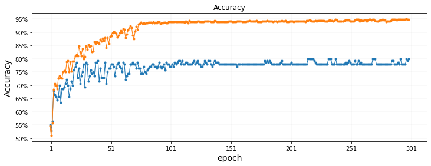

```python
t = np.array(acc_list)
v = np.array(train_acc_list)
fig,(ax1) = plt.subplots(1,1,figsize=(12,4))
ax1.plot(t,alpha=1,linewidth=1,marker='.')
ax1.plot(v,alpha=1,linewidth=1,marker='.')
ax1.grid(alpha=0.75,linewidth=0.2)
ax1.set_title("Accuracy")
ax1.set_xlabel(r'epoch',fontsize=14)
ax1.get_yaxis().set_major_formatter(matplotlib.ticker.FuncFormatter(lambda x, p: '%1.0f'%(x) + '%'))
ax1.set_ylabel(r'Accuracy',fontsize=14)
x = []
y = []
for i in range(100):
    if t[i]>=90:
        x.append(i)
        y.append(t[i])
        # ax1.text(i, t[i],'%1.2f'%(t[i]) + '%', fontsize=10, color="r", style="italic", weight="light", verticalalignment='center',horizontalalignment='right',rotation=45)
ax1.set_xticks(list(range(1,501,50)))
ax1.set_yticks(list(range(50,100,5)))
ax1.scatter(x,y,color="r")
plt.savefig(f"./2023样本24个品种成功率.png",dpi=1000,format='jpg')
plt.show()
```

```python
def prob_data(show_detail,id='test'):
    if (id != 'test'):
        data = torch.tensor(train_data_x)
        target = torch.tensor(y_train)
        col_list = col_train
    else:
        data = torch.tensor(test_data_x)
        target = torch.tensor(y_test)
        col_list = col_test
    del_col = []
    data = data.type(torch.FloatTensor)
    data, target = data.cuda(), target.cuda()
    data, target = Variable(data, volatile=True), Variable(target)
    output, probs = model(data)
    pred = probs.data.max(1, keepdim=True)[1]
    ans = pred.eq(target.view_as(pred)).cuda().flatten().tolist()
    for i in range(len(ans)):
        if (ans[i]==False) :
            del_col.append(col_list[i])
    return (pred.flatten().tolist(),ans,del_col)
```

```python
pred,ans,del_col = prob_data(True,'train')
df_ans = pd.DataFrame()
df_ans['ans'] = ans
df_ans['pred'] = pred
df_ans['target'] = y_train
df_ans['col_id'] = col_train
df_ans.to_csv('train_result3.csv',index=False)
```

```python
pred,ans,del_col = prob_data(True,'test')
df_ans = pd.DataFrame()
df_ans['ans'] = ans
df_ans['pred'] = pred
df_ans['target'] = y_test
df_ans['col_id'] = col_test
df_ans.to_csv('test_result3.csv',index=False)
```